# lecture1

- CS jobs when I was in first year vs now.
- What is Intelligence? Only found in humans or also in non-human animals?
- What is AI? Mostly marketing actually :3
- Empirical design vs Rule-based Design (Machine Learning vs Traditional Programming)
- XAI

# Python for C Programmers

## Powerful Calcualtor

```python
1 + 2
```

```
3
```

```python
5 ** 2
```

```
25
```

## No Types, No semicolons

```python
x = 1
```

## Print

```python
print(x)
```

```
1
```

## Indentation is not for style, it is the syntax.

`else if` -> `elif`

```python
if x == 1:
  print("X is one")
elif x == 2:
  print("X is two")
else:
  print("X is not one or two")
```

```
X is one
```

## `for` loop

```python
for i in range(10):
  print(i)
```

```
0
1
2
3
4
5
6
7
8
9
```

## Arrays -> List

```python
a = [2104121, 2104122, 2104123]
print(a)
```

```
[2104121, 2104122, 2104123]
```

```python
len(a)
```

```
3
```

```python
a[2]
```

```
2104123
```

```python
a.append(2104086)
print(a)
```

```
[2104121, 2104122, 2104123, 2104086]
```

```python
b = [1, 1.2, 'CUET', 5]
print(b)
```

```
[1, 1.2, 'CUET', 5]
```

```python
len(b)
```

```
4
```

```python
b[2]
```

```
'CUET'
```

```python
a + b
```

```
[2104121, 2104122, 2104123, 2104086, 1, 1.2, 'CUET', 5]
```

```python
a * 5
```

```
[2104121,
 2104122,
 2104123,
 2104086,
 2104121,
 2104122,
 2104123,
 2104086,
 2104121,
 2104122,
 2104123,
 2104086,
 2104121,
 2104122,
 2104123,
 2104086,
 2104121,
 2104122,
 2104123,
 2104086]
```

## Dictionary

```python
ids = {
  'Mahi': 2104121,
  'Zarif': 2104122,
  'Saimun': 2104123
}
```

```python
ids['Zarif']
```

```
2104122
```

```python
len(ids)
```

```
3
```

## List Comprehension

```python
squares = []

for i in range(10):
  squares.append(i**2)

print(squares)
```

```
[0, 1, 4, 9, 16, 25, 36, 49, 64, 81]
```

```python
squares = [i**2 for i in range(10)]
print(squares)
```

```
[0, 1, 4, 9, 16, 25, 36, 49, 64, 81]
```

(See practice problems)

# Maths

(Teach about vectors and Matrices in whiteboard)

## Practice: Matrix multiplication

```python
def matrix_multiplication(a, b):
  row_a = len(a)
  col_a = len(a[0])
  row_b = len(b)
  col_b = len(b[0])

  if (col_a != row_b):
    return "Error: Number of columns of the multiplicand should be the same as the number of rows of the multiplier"

  result = [[0] * col_b for i in range(row_a)]

  for i in range(row_a):
    for j in range(col_b):
      sum = 0
      for k in range(col_a):
        sum += a[i][k] * b[k][j]
      result[i][j] = sum
  return result

a = [
    [1, 2, 3],
    [4, 5, 6],
    [7, 8, 9]
]
b = [
    [10, 11, 12],
    [13, 14, 15],
    [16, 17, 18]
]

matrix_multiplication(a, b)
```

```
[[84, 90, 96], [201, 216, 231], [318, 342, 366]]
```

# Pytorch

Pytorch is written in C++.

So, the data types you learned in C++ are also available in Pytorch.

## Tensor & Operations on Tensors

```python
import torch

a = torch.tensor([1,2,3])
b = torch.tensor([4,5,6])

a + b
```

```
tensor([5, 7, 9])
```

```python
a - b
```

```
tensor([-3, -3, -3])
```

```python
a * b
```

```
tensor([ 4, 10, 18])
```

```python
a.dot(b)
```

```
tensor(32)
```

```python
A = torch.tensor([
    [1, 2, 3],
    [4, 5, 6]
])

B = torch.tensor([
    [7, 8],
    [9, 10],
    [11, 12]
])

A.mm(B)
```

```
tensor([[ 58,  64],
        [139, 154]])
```

```python
A @ B
```

```
tensor([[ 58,  64],
        [139, 154]])
```

```python
A.dot(B)
```

```
---------------------------------------------------------------------------
RuntimeError                              Traceback (most recent call last)
Cell In[28], line 1
----> 1 A.dot(B)

RuntimeError: 1D tensors expected, but got 2D and 2D tensors
```

```python
A.mT
```

```
tensor([[1, 4],
        [2, 5],
        [3, 6]])
```

```python
A.shape
```

```
torch.Size([2, 3])
```

```python
A.reshape(6, 1)
```

```
tensor([[1],
        [2],
        [3],
        [4],
        [5],
        [6]])
```

```python
A.reshape(-1, 1)
```

```
tensor([[1],
        [2],
        [3],
        [4],
        [5],
        [6]])
```

```python
A.tolist()
```

```
[[1, 2, 3], [4, 5, 6]]
```

```python
a, b
```

```
(tensor([1, 2, 3]), tensor([4, 5, 6]))
```

```python
a.T
```

```
tensor([1, 2, 3])
```

```python
a.shape
```

```
torch.Size([3])
```

```python
a = a.reshape(-1, 1)
b = b.reshape(-1, 1)

print(a.shape)
print(b.shape)
```

```
torch.Size([3, 1])
torch.Size([3, 1])
```

```python
a
```

```
tensor([[1],
        [2],
        [3]])
```

```python
a.T.mm(b)
```

```
tensor([[32]])
```

## Common Tensors

```python
torch.zeros(1, 3)
```

```
tensor([[0., 0., 0.]])
```

```python
torch.ones(1, 4)
```

```
tensor([[1., 1., 1., 1.]])
```

```python
torch.rand(1, 2)
```

```
tensor([[0.3650, 0.0908]])
```

```python
torch.randn(1, 5)
```

```
tensor([[-0.8649, -0.1168,  0.5873, -0.1091, -0.2809]])
```

```python
torch.eye(3, 3)
```

```
tensor([[1., 0., 0.],
        [0., 1., 0.],
        [0., 0., 1.]])
```

```python
torch.arange(0, 10, 2)
```

```
tensor([0, 2, 4, 6, 8])
```

```python
torch.linspace(0, 10, 21)
```

```
tensor([ 0.0000,  0.5000,  1.0000,  1.5000,  2.0000,  2.5000,  3.0000,  3.5000,
         4.0000,  4.5000,  5.0000,  5.5000,  6.0000,  6.5000,  7.0000,  7.5000,
         8.0000,  8.5000,  9.0000,  9.5000, 10.0000])
```

```python
x = torch.arange(0, 10, 2)
x ** 2
```

```
tensor([ 0,  4, 16, 36, 64])
```

## Reproducibility

```python
torch.manual_seed(42)
torch.rand(2, 2)
```

```
tensor([[0.8823, 0.9150],
        [0.3829, 0.9593]])
```

## 0D Tensors

```python
x = torch.tensor(5)
x
```

```
tensor(5)
```

```python
x.item()
```

```
5
```

## Slicing

```python
x = torch.arange(0, 9).reshape(3, 3)
x
```

```
tensor([[0, 1, 2],
        [3, 4, 5],
        [6, 7, 8]])
```

```python
x[0]
```

```
tensor([0, 1, 2])
```

```python
x[0, :]
```

```
tensor([0, 1, 2])
```

```python
x[:, 0]
```

```
tensor([0, 3, 6])
```

```python
x[0, 0]
```

```
tensor(0)
```

## `add` vs `add_`

```python
a = torch.tensor([1, 2, 3])
b = torch.tensor([4, 5, 6])

a.add(b)
```

```
tensor([5, 7, 9])
```

```python
a
```

```
tensor([1, 2, 3])
```

```python
a.add_(b)
```

```
tensor([5, 7, 9])
```

```python
a
```

```
tensor([5, 7, 9])
```

## Autograd

```python
x = torch.tensor(4.0, requires_grad=True)
y = x**2 + 5
y.backward()
print(x.grad)
```

```
tensor(8.)
```

- `requires_grad` just tells pytorch, "hey pytorch, watch this variable x. i will later ask you to differentiate w.r.t this"
- `y = x**2 + 5` is a function of x. In the background, pytorch also creates and stores a "computational graph" - which is just a fancy way to say that, pytorch does not only calculate the value of y, but also remembers the formula... because, duh, we need the formula to figure out the derivative.
- `y.backward()` asks pytorch to calculate the gradient of y w.r.t x
- But where is the gradient stored? in `x.grad`

```python
x = torch.tensor(4.0, requires_grad=True)
y = torch.abs(x - 4)
y.backward()
print(x.grad)
```

```
tensor(0.)
```

```python
m = torch.tensor(2., requires_grad=True)
x = torch.tensor(4., requires_grad=True)
b = torch.tensor(3., requires_grad=True)
```

```python
x.requires_grad_(False)
```

```
tensor(4.)
```

```python
y = m * x + b
y.backward()
```

```python
print(m.grad)
print(x.grad)
print(b.grad)
```

```
tensor(4.)
None
tensor(1.)
```

So how does it calculate the gradient? Chain rule!

Suppose you want to have $f(x) = a(b(x))$  
Then $\frac{df}{dx} = \frac{da}{db} \times \frac{db}{dx}$

Example:  
Let, $a(x) = cos(x)$ and $b(x) = x^2$  
Then, $f(x) = \cos(x^2)$

Therefore,  
$\frac{df}{dx} = \frac{d\cos(x^2)}{dx} = \frac{d\cos(x^2)}{d(x^2)} \times \frac{d(x^2)}{dx} = -\sin(x^2) \times 2x$

# Matplotlib

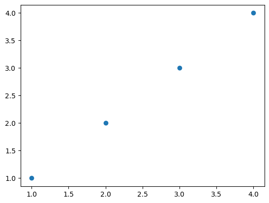

```python
import matplotlib.pyplot as plt

plt.plot([1, 2, 3, 4], [1, 2, 3, 4], 'o')
```

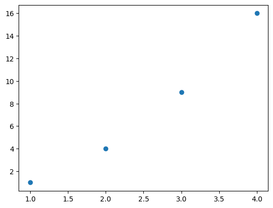

```python
plt.plot([1, 2, 3, 4], [1, 4, 9, 16], 'o')
```

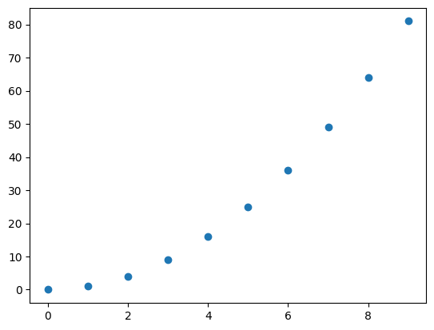

```python
plt.plot(torch.arange(10), torch.arange(10) ** 2, 'o')
```

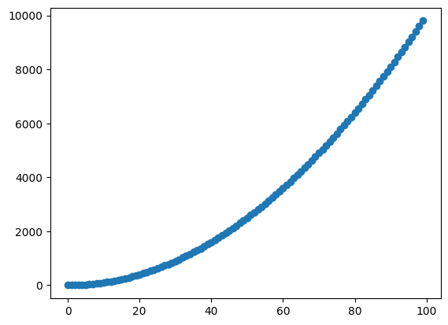

```python
plt.plot(torch.arange(100), torch.arange(100) ** 2, 'o')
```

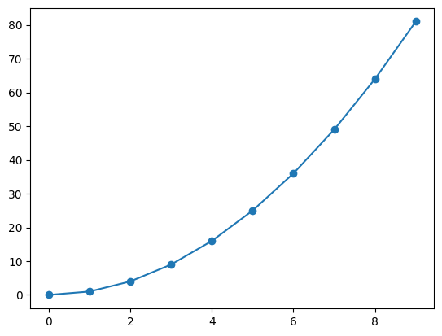

```python
plt.plot(torch.arange(10), torch.arange(10) ** 2, 'o-')
```

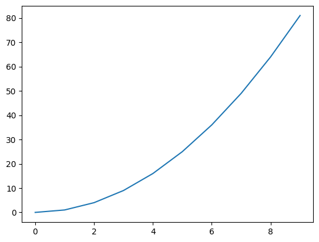

```python
plt.plot(torch.arange(10), torch.arange(10) ** 2, '-')
```

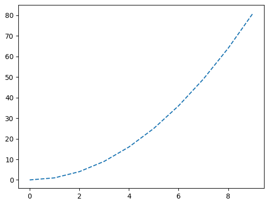

```python
plt.plot(torch.arange(10), torch.arange(10) ** 2, '--')
```

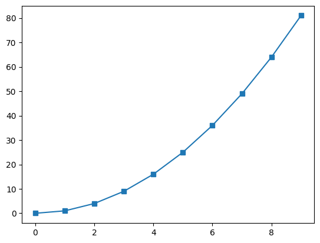

```python
plt.plot(torch.arange(10), torch.arange(10) ** 2, 's-')
```

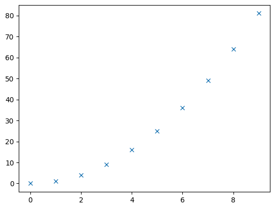

```python
plt.plot(torch.arange(10), torch.arange(10) ** 2, 'x')
```

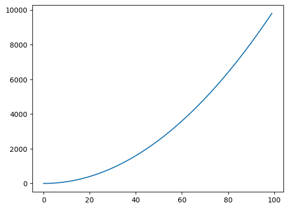

```python
plt.plot(torch.arange(100), torch.arange(100) ** 2);
```

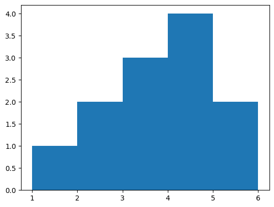

```python
plt.hist([1,2,2,3,3,3,4,4,4,4,5,5], bins=range(1, 7));
```

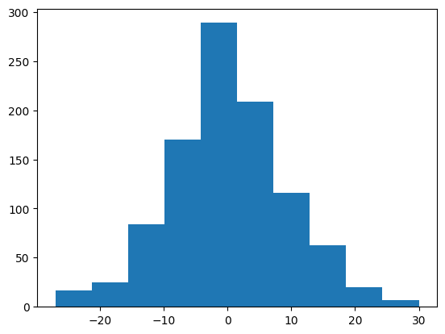

```python
plt.hist((torch.randn(1000) * 10).type(torch.int));
```

# Ipywidget

```python
from ipywidgets import interact

@interact(a=1.5, b=1.5, c=1.5)
def plot(a, b, c):
    x = torch.linspace(-10, 10, 100)
    y = a * x**2 + b * x + c
    plt.xlim(-10, 10)
    plt.ylim(-10, 10)
    plt.plot(x, y)
    plt.show()
```

```
interactive(children=(FloatSlider(value=1.5, description='a', max=4.5, min=-1.5), FloatSlider(value=1.5, descr…
```

```python
@interact(start=5, end=10, step=1)
def print_range(start, end):
    print(torch.arange(start, end))
```

```
interactive(children=(IntSlider(value=5, description='start', max=15, min=-5), IntSlider(value=10, description…
```

# More on matplotlib

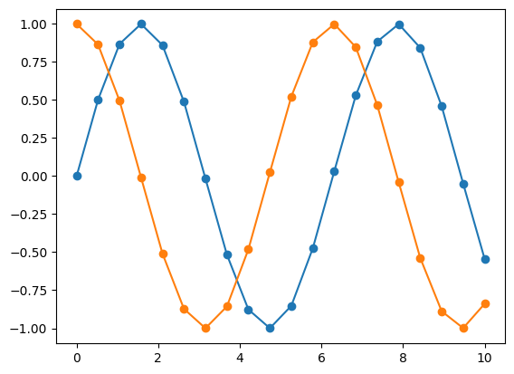

```python
x = torch.linspace(0, 10, 20)
y1 = torch.sin(x)
y2 = torch.cos(x)

plt.plot(x, y1, 'o-')
plt.plot(x, y2, 'o-')
plt.show()
```

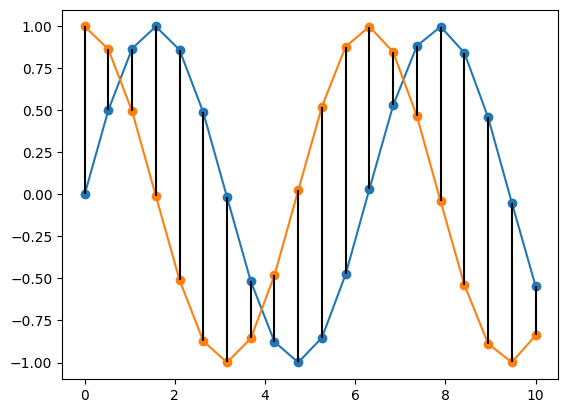

```python
plt.plot(x, y1, 'o-')
plt.plot(x, y2, 'o-')
plt.vlines(x, y1, y2, 'k')
plt.show()
```

```python
x = torch.linspace(0, 10, 1000)
y1 = torch.sin(x)

@interact(phase = (0, 2, 0.01))
def plot(phase):
    y2 = torch.cos(x + phase * 3.14)
    plt.plot(x, y1)
    plt.plot(x, y2)
    plt.vlines(x, y1, y2, 'r', alpha=0.1)
    plt.show()
```

```
interactive(children=(FloatSlider(value=1.0, description='phase', max=2.0, step=0.01), Output()), _dom_classes…
```